# Lab 2

Jeffrey Stevenson

2021-02-17

# Tasks

## Task 1

```r
getwd()
```

```
## [1] "C:/Users/jeffr/OneDrive/Desktop/School/Spring 2021/Statistics/MATH4753stev0009/Labs/LAB2"
```

## Task 2

```r
EPAGAS <- read.csv("EPAGAS.csv")
head(EPAGAS)
```

```
##    MPG
## 1 36.3
## 2 41.0
## 3 36.9
## 4 37.1
## 5 44.9
## 6 36.8
```

## Task 3

```r
mpg <- EPAGAS$MPG
```

```r
z <- (mpg-mean(mpg))/sd(mpg)
print(paste0("mean = ", round(mean(z), 4)), quote = 'FALSE')
```

```
## [1] mean = 0
```

```r
print(paste0("variance = ", var(z)), quote = 'FALSE')
```

```
## [1] variance = 1
```

```r
print(paste0("standard deviation = ", sd(z)), quote = 'FALSE')
```

```
## [1] standard deviation = 1
```

Possible Outliers:

```r
mpg[abs(z)>=2 & abs(z)<=3]
```

```
## [1] 30.0 42.1 31.8
```

Definite Outliers:

```r
mpg[abs(z)>3]
```

```
## [1] 44.9
```

Dotplot

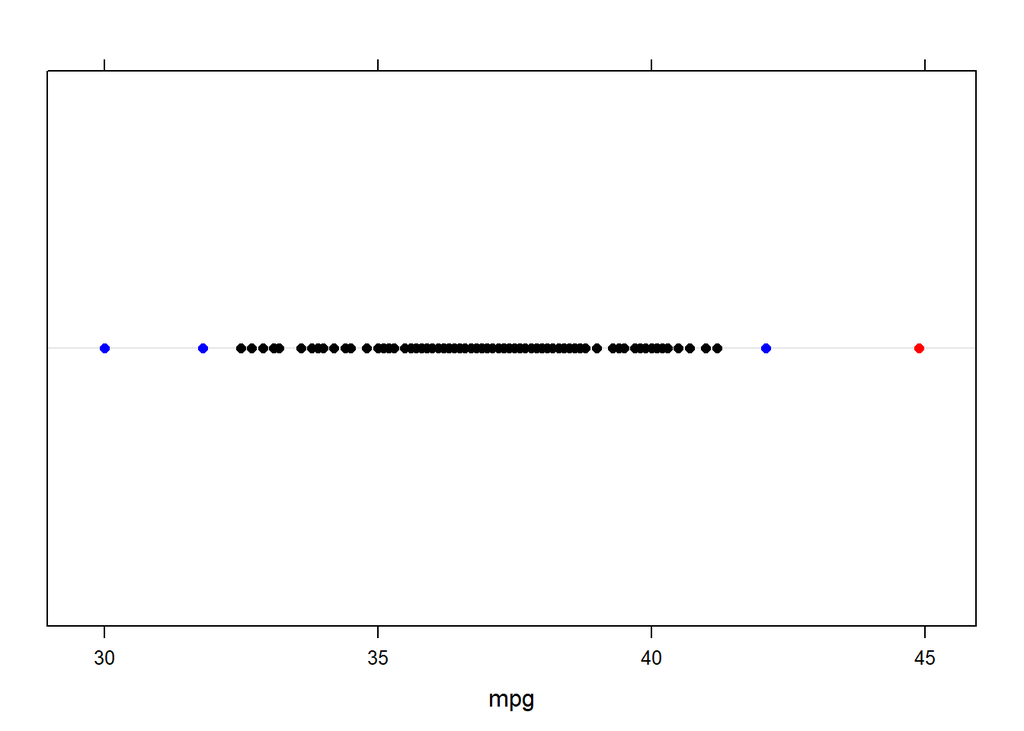

```r
library(lattice)
mycol = ifelse(abs(z)>3, "Red",
        ifelse(abs(z)>=2 & abs(z)<=3,"Blue", "Black"))
dotplot(mpg, col = mycol)
```

## Task 4

1. Boxplot

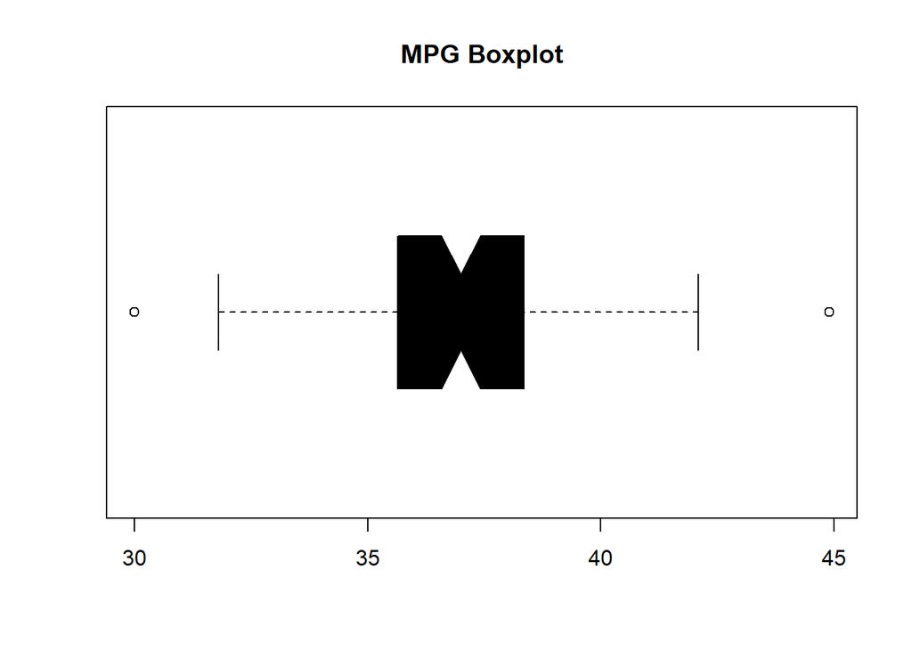

```r
boxplot(mpg, notch = TRUE, horizontal = TRUE, col = 'black', main='MPG Boxplot')
```

2. Proportion of data within 2 standard deviations of the mean of the mpg data:

```r
k = 2
prop = 1-(1/k^2)
prop
```

```
## [1] 0.75
```

3. Exact proportion within 2 standard deviation of the mean:

```r
prop1 = length(mpg[abs(z)<=2])/length(mpg)
prop1
```

```
## [1] 0.96
```

4. According to Chebysev’s theorem, at least 75% of the data lies within 2 standard deviations of the mean. This agrees with the data, with 96% of the data lying withing 2 standard deviations of the mean.
5. What proportion (according to the rule) of the data should be within 2 standard deviations of the mean?

95% of data should be within 2 standard deviations of the mean.

6. How well does it correspond?

It corresponds well (as calculated above, 96% of the data lies within 2 standard deviations of the mean).

7. Is the Empirical rule valid in this case? Why?

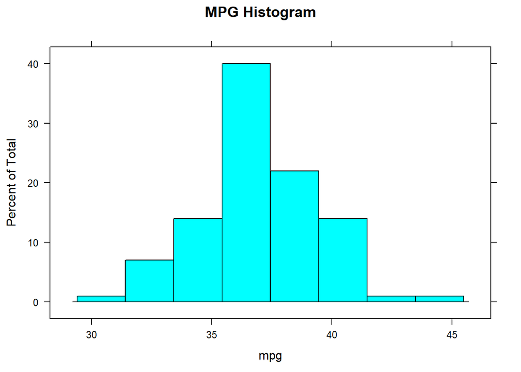

```r
histogram(mpg, main = 'MPG Histogram')
```